# Tarea 1 Estadística y Probabilidad

## Ejercicio 9.4 Temperatura en grados Celsius

### Datos

```r
temperatura<- c(20.1, 23.1, 30.6, 32.3, 31.7, 5, 21.1, 27.4, 21.3, 29, 19.8, 15.3, 28.7, 25.1, 14.3, 23.3, 28.7, 17.7, 30.3, 26.7, 26.2, 11.4, 25.5, 15, 23.8, 23.9, 16.2, 26, 12.7, 32.8, 19.2, 37.2, 10.3, 25, 14.9, 30.9, 19, 23.64, 24.1, 13.1, 17.6, 31.9, 25.7, 13.6, 21.6, 14.4, 29.5, 7.75, 33.7, 35.2)
```

### Procesamiento de datos (Ordenar)

Primero obtenemos un resumen de los datos generados

```r
summary(temperatura)
```

```
##    Min. 1st Qu.  Median    Mean 3rd Qu.    Max.
##    5.00   16.55   23.72   22.67   28.70   37.20
```

Al ser variables de tipo cuantitativa discretas se pueden ordenar.

### Frecuencias (Clasificar)

Obtenemos las frecuencias de los datos.

```r
(temperatura) #Datos
```

```
##  [1] 20.10 23.10 30.60 32.30 31.70  5.00 21.10 27.40 21.30 29.00 19.80 15.30
## [13] 28.70 25.10 14.30 23.30 28.70 17.70 30.30 26.70 26.20 11.40 25.50 15.00
## [25] 23.80 23.90 16.20 26.00 12.70 32.80 19.20 37.20 10.30 25.00 14.90 30.90
## [37] 19.00 23.64 24.10 13.10 17.60 31.90 25.70 13.60 21.60 14.40 29.50  7.75
## [49] 33.70 35.20
```

```r
temperatura_ord<- sort(temperatura) #Datos ordenados por clase
(temperatura_ord)
```

```
##  [1]  5.00  7.75 10.30 11.40 12.70 13.10 13.60 14.30 14.40 14.90 15.00 15.30
## [13] 16.20 17.60 17.70 19.00 19.20 19.80 20.10 21.10 21.30 21.60 23.10 23.30
## [25] 23.64 23.80 23.90 24.10 25.00 25.10 25.50 25.70 26.00 26.20 26.70 27.40
## [37] 28.70 28.70 29.00 29.50 30.30 30.60 30.90 31.70 31.90 32.30 32.80 33.70
## [49] 35.20 37.20
```

```r
contador <- table(temperatura) #Frecuencia de los datos
(contador)
```

```
## temperatura
##     5  7.75  10.3  11.4  12.7  13.1  13.6  14.3  14.4  14.9    15  15.3  16.2
##     1     1     1     1     1     1     1     1     1     1     1     1     1
##  17.6  17.7    19  19.2  19.8  20.1  21.1  21.3  21.6  23.1  23.3 23.64  23.8
##     1     1     1     1     1     1     1     1     1     1     1     1     1
##  23.9  24.1    25  25.1  25.5  25.7    26  26.2  26.7  27.4  28.7    29  29.5
##     1     1     1     1     1     1     1     1     1     1     2     1     1
##  30.3  30.6  30.9  31.7  31.9  32.3  32.8  33.7  35.2  37.2
##     1     1     1     1     1     1     1     1     1     1
```

```r
cte<- 9
```

### Proporciones

Obtenemos las proporciones.

```r
prop.table(table(temperatura)) #Proporciones
```

```
## temperatura
##     5  7.75  10.3  11.4  12.7  13.1  13.6  14.3  14.4  14.9    15  15.3  16.2
##  0.02  0.02  0.02  0.02  0.02  0.02  0.02  0.02  0.02  0.02  0.02  0.02  0.02
##  17.6  17.7    19  19.2  19.8  20.1  21.1  21.3  21.6  23.1  23.3 23.64  23.8
##  0.02  0.02  0.02  0.02  0.02  0.02  0.02  0.02  0.02  0.02  0.02  0.02  0.02
##  23.9  24.1    25  25.1  25.5  25.7    26  26.2  26.7  27.4  28.7    29  29.5
##  0.02  0.02  0.02  0.02  0.02  0.02  0.02  0.02  0.02  0.02  0.04  0.02  0.02
##  30.3  30.6  30.9  31.7  31.9  32.3  32.8  33.7  35.2  37.2
##  0.02  0.02  0.02  0.02  0.02  0.02  0.02  0.02  0.02  0.02
```

### Medidas de tendencia central

#### Moda

Obtenemos la moda

```r
# Función para detectar modalidad
max_frecuencia <- max(contador)
modas <- names(contador)[contador == max_frecuencia]

# Identificar e imprimir resultado
if(length(modas) == 1) {
  cat("UNIMODAL - Moda:", modas)
} else if(length(modas) == 2) {
  cat("BIMODAL - Modas:", paste(modas, collapse = " y "))
} else {
  cat("Hay más de dos clases con mayor frecuencia por lo tanto no hay moda")
}
```

```
## UNIMODAL - Moda: 28.7
```

#### Mediana

Obtenemos la mediana

```r
  # Calcular mediana
  mediana<- median(temperatura)
  cat("La mediana es:", mediana, "\n")
```

```
## La mediana es: 23.72
```

#### Media

Obtenemos la media

```r
media<-mean(temperatura)
cat("La media es:", media, "\n")
```

```
## La media es: 22.6658
```

### Medidas de localización

#### Cuartiles

```r
cuantiles <- quantile(temperatura_ord); (cuantiles)
```

```
##    0%   25%   50%   75%  100%
##  5.00 16.55 23.72 28.70 37.20
```

```r
Q1 <- cuantiles[2]; (Q1)
```

```
##   25%
## 16.55
```

```r
Q2 <- cuantiles[3]; (Q2)
```

```
##   50%
## 23.72
```

```r
Q3 <- cuantiles[4]; (Q3)
```

```
##  75%
## 28.7
```

Calculemos el valor máximo y el valor mínimo para los datos

```r
mi_min <- min(temperatura);
(mi_min)
```

```
## [1] 5
```

```r
mi_max <- max(temperatura);
(mi_max)
```

```
## [1] 37.2
```

### Diagrama de caja y brazos

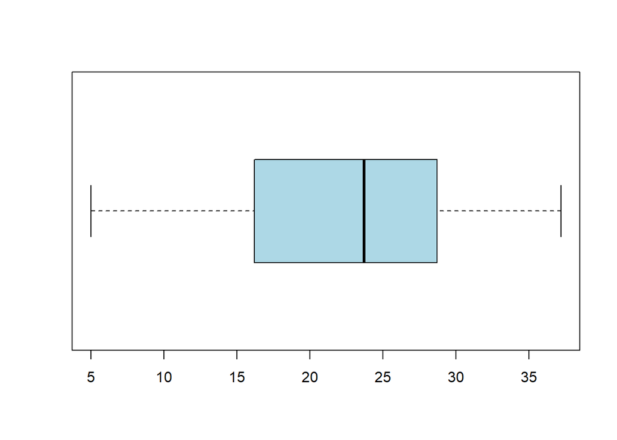

```r
boxplot(temperatura_ord, horizontal = TRUE, col = "lightblue")
```

### Medidas de dispersión

#### Varianza

```r
varianza <- var(temperatura); (varianza)
```

```
## [1] 57.86485
```

#### Desviación estándar

```r
DesvEst <- sd(temperatura); (DesvEst)
```

```
## [1] 7.606895
```

### Gráficos

Comenzamos a graficar.

#### Generemos la gráfica de barras.

```r
# Regla de Sturges lo que nos da el número de intervalos
n <- length(temperatura)
nbreaks <- round(1 + 3.322 * log10(n))
(nbreaks)
```

```
## [1] 7
```

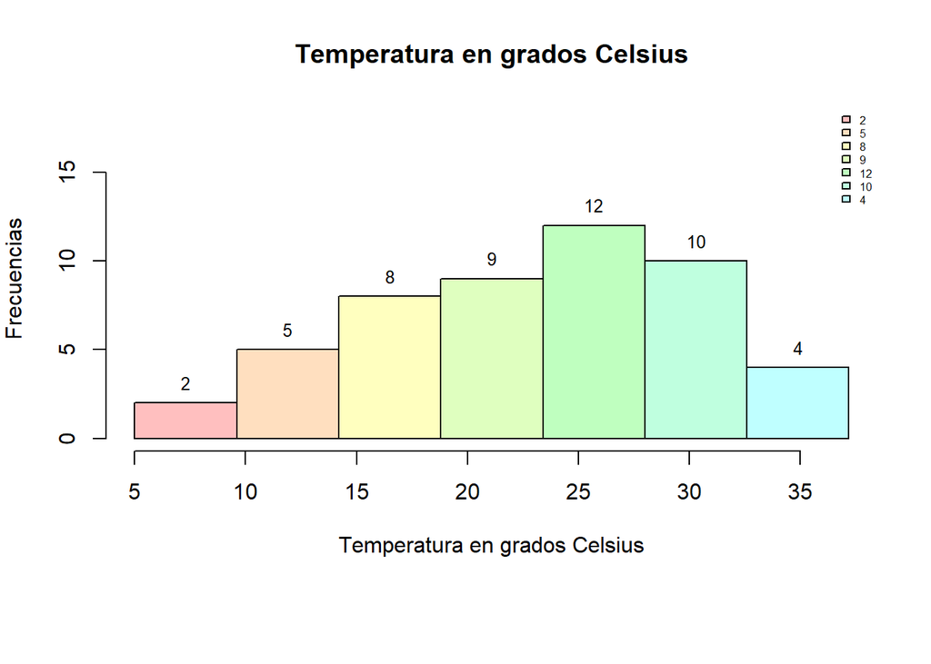

```r
rango <- range(temperatura)
breaks_exactos <- seq(from = rango[1], to = rango[2], length.out = nbreaks + 1)

par(mar=c(8,4,4,2))
miscolores <- rainbow(12,0.25)
gb <- hist(temperatura, breaks = breaks_exactos, plot = FALSE) #histograma simple de los datos
gb2 <- hist(temperatura, breaks = breaks_exactos, col = miscolores,
          main = "Temperatura en grados Celsius",
          xlab = "Temperatura en grados Celsius",
          ylab = "Frecuencias",
          ylim = c(0, max(gb$counts)*1.5))

text(gb2$mids, gb2$counts, labels = gb2$counts, pos = 3, cex = 0.8,
     col = "black")

nl <- length(gb2$counts)
legend(
  "topright",
  legend = gb2$counts,
  fill = miscolores[1:nl],  # Solo los colores necesarios
  pt.cex = 1.5,
  cex = 0.5,
  bty = "n"
)
```

#### Gráfica de porcentajes

Generamos la gráfica de porcentajes.

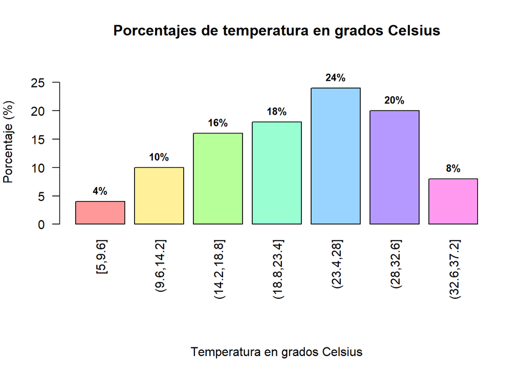

```r
par(mar=c(10,4,4,2))

intervalos <- cut(temperatura, breaks = breaks_exactos, include.lowest = TRUE)
tabla_intervalos <- table(intervalos)
porcentajes_intervalos <- round(prop.table(tabla_intervalos) * 100, 1)
gp <- barplot(porcentajes_intervalos,
                 col = rainbow(length(tabla_intervalos), 0.4),
                 main = "Porcentajes de temperatura en grados Celsius",
                 xlab = "",
                 ylab = "Porcentaje (%)",
                 ylim = c(0, max(porcentajes_intervalos) + 5),
                 las = 2)  # Etiquetas verticales

title(xlab = "Temperatura en grados Celsius", line = 8)

# Agregar valores encima de barras
text(x = gp,
     y = porcentajes_intervalos,
     labels = paste0(porcentajes_intervalos, "%"),
     pos = 3,
     cex = 0.8,
     font = 2)
```

#### Gráfica de pasteles

Generamos la gráfica de pasteles.

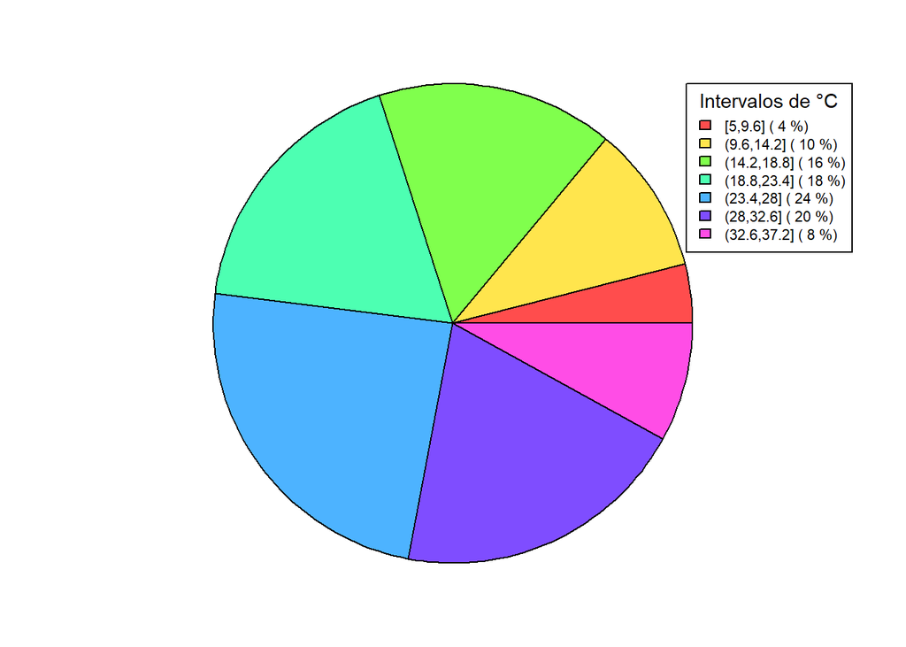

```r
par(pin = c(7, 5))
pie(tabla_intervalos,
    main = "Distribución de temperaturas en °C",
    col = rainbow(length(tabla_intervalos), 0.7),
    labels = NA,
    cex.main = 1.5)

legend(x =0.78, y = 0.8,
       legend = paste(names(tabla_intervalos), "(", porcentajes_intervalos, "%)"),
       fill = rainbow(length(tabla_intervalos), 0.7),
       cex = 0.7,
       title = "Intervalos de °C",
       title.cex = 0.9)
```

#### Gráfica de ojiva

Generamos la gráfica de ojiva

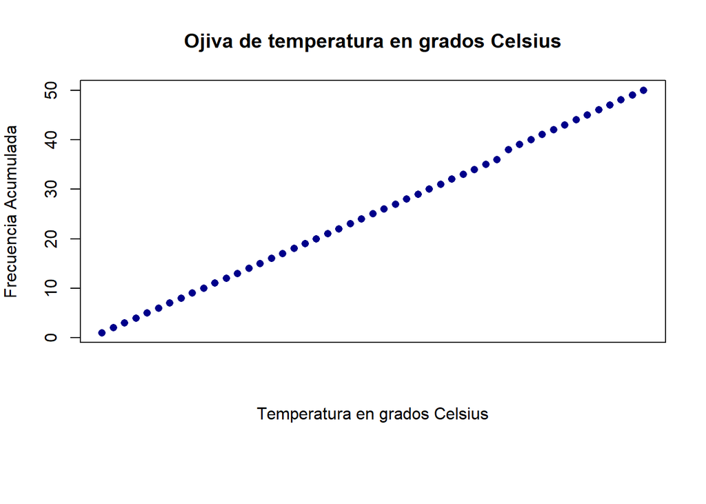

```r
par(mar=c(8,4,4,2))
frec_acum <- cumsum(table(factor(temperatura)))
plot(frec_acum, type = "b", pch = 16, col = "darkblue",
     main = "Ojiva de temperatura en grados Celsius",
     xlab = "Temperatura en grados Celsius",
     ylab = "Frecuencia Acumulada",
     xaxt = "n")
```

#### Gráfica de dispersión

```r
indices <- 1:10; (indices)
```

```
##  [1]  1  2  3  4  5  6  7  8  9 10
```

```r
t <- cte*indices; (t)
```

```
##  [1]  9 18 27 36 45 54 63 72 81 90
```

```r
mis_deciles <- tabla_intervalos[t]; (mis_deciles)
```

```
## intervalos
## <NA> <NA> <NA> <NA> <NA> <NA> <NA> <NA> <NA> <NA>
##
```

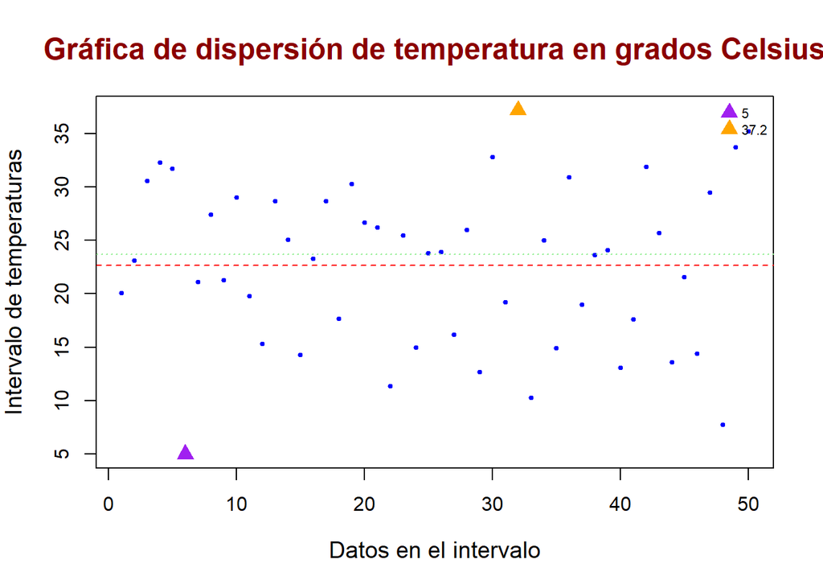

```r
plot(temperatura,
  main = "Gráfica de dispersión de temperatura en grados Celsius",
  xlab = "Datos en el intervalo",
  ylab = "Intervalo de temperaturas",
  col = "blue",
  pch = 19,
  cex = 0.5,
  cex.main = 1.5,
  cex.lab = 1.2,
  col.main = "darkred")
legend(
  "topright",                  # ubicación
  legend = c(mi_min,mi_max),    # etiquetas
  pch = 17,
  col=c("purple","orange"),
  pt.cex = 1.5,                # tamaño de los símbolos
  cex = 0.7,
  bty = "n"                    # sin borde en la caja
)
abline(h = media, col = "red", lwd = 1, lty = 2)
abline(h = Q2, col = "lightgreen", lwd = 1, lty = 3)
abline(h = mis_deciles, col = "lightgray", lty = 1.5)
points(which.min(temperatura), min(temperatura), col = "purple", pch = 17, cex = 1.5)
points(which.max(temperatura), max(temperatura), col = "orange", pch = 17, cex = 1.5)
```

#### Gráfica combinada

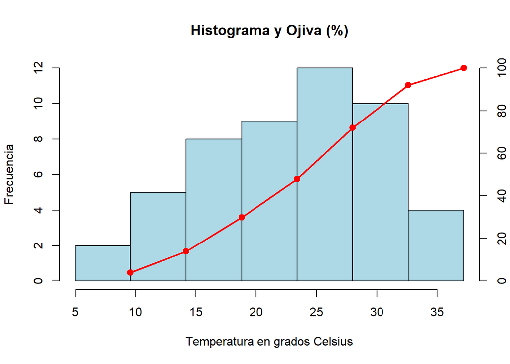

```r
nbreaks <- 10
h <- hist(temperatura, breaks = breaks_exactos, plot = FALSE)
hist(temperatura,
     breaks = breaks_exactos,
     col = "lightblue",
     main = "Histograma y Ojiva (%)",
     xlab = "Temperatura en grados Celsius",
     ylab = "Frecuencia")
freq_acum_pct <- cumsum(h$counts) / sum(h$counts) * 100
x_vals <- h$breaks[-1]
par(new = TRUE)
plot(x_vals, freq_acum_pct,
     type = "o", pch = 19, lwd = 2, col = "red",
     axes = FALSE, xlab = "", ylab = "",
     xlim = range(h$breaks), ylim = c(0, 100))
axis(4)                           # eje derecho
```

```r
#---- Fin ----
```

## Ejercicio 9.5 Tiempos de traslado en horas

### Datos

```r
horas<- c(1.5, 1.3, 1.1, 0.6, 0.9, 1.4, 0.8, 1.7, 1.7, 1.6, 1.7, 1.3, 1.5, 0.5, 1.4, 0.6, 1.5, 1.9, 0.7, 1.9, 2, 1.6, 0.7, 1.6, 0.7, 0.5, 0.6, 1.6, 1.4, 1.9, 1.9, 1, 1.7, 1.7, 1.8, 1.6, 1.4, 1.4, 0.7, 0.8, 1.5, 0.8, 1.9, 1.2, 1.9, 1.8, 1.7, 1.5, 1.5, 0.7, 1.8, 1.3, 1.8, 0.6, 1.5, 1.4, 1.3, 1.3, 0.8, 1.4, 0.6, 1.1, 1.1, 0.6, 1.7, 0.5, 2, 1.7, 0.7, 1, 0.6, 1.8, 1.1, 1.6, 1, 1.1, 1.8, 0.8, 1.1, 1.7, 1.4, 1.4, 1.2, 1.5, 1.6, 1.6, 1.5, 0.5, 1.4, 1.1, 1, 0.9, 0.6, 1.7, 1.6, 1.2, 0.6, 1.2, 1.2, 1.8)
```

### Procesamiento de datos (Ordenar)

Primero obtenemos un resumen de los datos generados

```r
summary(horas)
```

```
##    Min. 1st Qu.  Median    Mean 3rd Qu.    Max.
##   0.500   0.900   1.400   1.285   1.625   2.000
```

Al ser variables de tipo cuantitativa discretas se pueden ordenar.

### Frecuencias (Clasificar)

Obtenemos las frecuencias de los datos.

```r
(horas) #Datos
```

```
##   [1] 1.5 1.3 1.1 0.6 0.9 1.4 0.8 1.7 1.7 1.6 1.7 1.3 1.5 0.5 1.4 0.6 1.5 1.9
##  [19] 0.7 1.9 2.0 1.6 0.7 1.6 0.7 0.5 0.6 1.6 1.4 1.9 1.9 1.0 1.7 1.7 1.8 1.6
##  [37] 1.4 1.4 0.7 0.8 1.5 0.8 1.9 1.2 1.9 1.8 1.7 1.5 1.5 0.7 1.8 1.3 1.8 0.6
##  [55] 1.5 1.4 1.3 1.3 0.8 1.4 0.6 1.1 1.1 0.6 1.7 0.5 2.0 1.7 0.7 1.0 0.6 1.8
##  [73] 1.1 1.6 1.0 1.1 1.8 0.8 1.1 1.7 1.4 1.4 1.2 1.5 1.6 1.6 1.5 0.5 1.4 1.1
##  [91] 1.0 0.9 0.6 1.7 1.6 1.2 0.6 1.2 1.2 1.8
```

```r
horas_ord<- sort(horas) #Datos ordenados por clase
(horas_ord)
```

```
##   [1] 0.5 0.5 0.5 0.5 0.6 0.6 0.6 0.6 0.6 0.6 0.6 0.6 0.6 0.7 0.7 0.7 0.7 0.7
##  [19] 0.7 0.8 0.8 0.8 0.8 0.8 0.9 0.9 1.0 1.0 1.0 1.0 1.1 1.1 1.1 1.1 1.1 1.1
##  [37] 1.1 1.2 1.2 1.2 1.2 1.2 1.3 1.3 1.3 1.3 1.3 1.4 1.4 1.4 1.4 1.4 1.4 1.4
##  [55] 1.4 1.4 1.4 1.5 1.5 1.5 1.5 1.5 1.5 1.5 1.5 1.5 1.6 1.6 1.6 1.6 1.6 1.6
##  [73] 1.6 1.6 1.6 1.7 1.7 1.7 1.7 1.7 1.7 1.7 1.7 1.7 1.7 1.8 1.8 1.8 1.8 1.8
##  [91] 1.8 1.8 1.9 1.9 1.9 1.9 1.9 1.9 2.0 2.0
```

```r
contador <- table(horas) #Frecuencia de los datos
(contador)
```

```
## horas
## 0.5 0.6 0.7 0.8 0.9   1 1.1 1.2 1.3 1.4 1.5 1.6 1.7 1.8 1.9   2
##   4   9   6   5   2   4   7   5   5  10   9   9  10   7   6   2
```

```r
cte<- 9
```

### Proporciones

Obtenemos las proporciones.

```r
prop.table(table(horas)) #Proporciones
```

```
## horas
##  0.5  0.6  0.7  0.8  0.9    1  1.1  1.2  1.3  1.4  1.5  1.6  1.7  1.8  1.9    2
## 0.04 0.09 0.06 0.05 0.02 0.04 0.07 0.05 0.05 0.10 0.09 0.09 0.10 0.07 0.06 0.02
```

### Medidas de tendencia central

#### Moda

Obtenemos la moda

```r
# Función para detectar modalidad
max_frecuencia <- max(contador)
modas <- names(contador)[contador == max_frecuencia]

# Identificar e imprimir resultado
if(length(modas) == 1) {
  cat("UNIMODAL - Moda:", modas)
} else if(length(modas) == 2) {
  cat("BIMODAL - Modas:", paste(modas, collapse = " y "))
} else {
  cat("Hay más de dos clases con mayor frecuencia por lo tanto no hay moda")
}
```

```
## BIMODAL - Modas: 1.4 y 1.7
```

#### Mediana

Obtenemos la mediana

```r
  # Calcular mediana
  mediana<- median(horas)
  cat("La mediana es:", mediana, "\n")
```

```
## La mediana es: 1.4
```

#### Media

Obtenemos la media

```r
media<-mean(horas)
cat("La media es:", media, "\n")
```

```
## La media es: 1.285
```

### Medidas de localización

#### Cuartiles

```r
cuantiles <- quantile(horas_ord); (cuantiles)
```

```
##    0%   25%   50%   75%  100%
## 0.500 0.900 1.400 1.625 2.000
```

```r
Q1 <- cuantiles[2]; (Q1)
```

```
## 25%
## 0.9
```

```r
Q2 <- cuantiles[3]; (Q2)
```

```
## 50%
## 1.4
```

```r
Q3 <- cuantiles[4]; (Q3)
```

```
##   75%
## 1.625
```

Calculemos el valor máximo y el valor mínimo para los datos

```r
mi_min <- min(horas);
(mi_min)
```

```
## [1] 0.5
```

```r
mi_max <- max(horas);
(mi_max)
```

```
## [1] 2
```

### Diagrama de caja y brazos

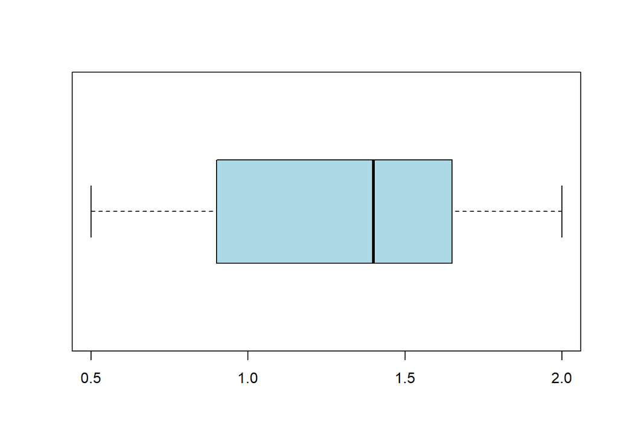

```r
boxplot(horas_ord, horizontal = TRUE, col = "lightblue")
```

### Medidas de dispersión

#### Varianza

```r
varianza <- var(horas); (varianza)
```

```
## [1] 0.1932071
```

#### Desviación estándar

```r
DesvEst <- sd(horas); (DesvEst)
```

```
## [1] 0.4395533
```

### Gráficos

Comenzamos a graficar.

#### Generemos la gráfica de barras.

```r
# Regla de Sturges lo que nos da el número de intervalos
n <- length(horas)
nbreaks <- round(1 + 3.322 * log10(n))
(nbreaks)
```

```
## [1] 8
```

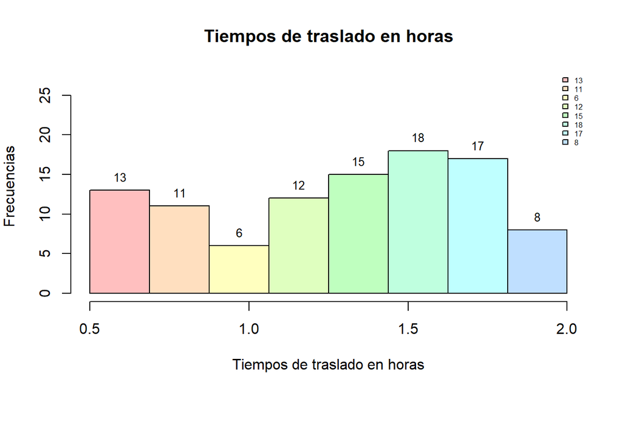

```r
rango <- range(horas)
breaks_exactos <- seq(from = rango[1], to = rango[2], length.out = nbreaks + 1)

par(mar=c(8,4,4,2))
miscolores <- rainbow(12,0.25)
gb <- hist(horas, breaks = breaks_exactos, plot = FALSE) #histograma simple de los datos
gb2 <- hist(horas, breaks = breaks_exactos, col = miscolores,
          main = "Tiempos de traslado en horas",
          xlab = "Tiempos de traslado en horas",
          ylab = "Frecuencias",
          ylim = c(0, max(gb$counts)*1.5))

text(gb2$mids, gb2$counts, labels = gb2$counts, pos = 3, cex = 0.8,
     col = "black")

nl <- length(gb2$counts)
legend(
  "topright",
  legend = gb2$counts,
  fill = miscolores[1:nl],  # Solo los colores necesarios
  pt.cex = 1.5,
  cex = 0.5,
  bty = "n"
)
```

#### Gráfica de porcentajes

Generamos la gráfica de porcentajes.

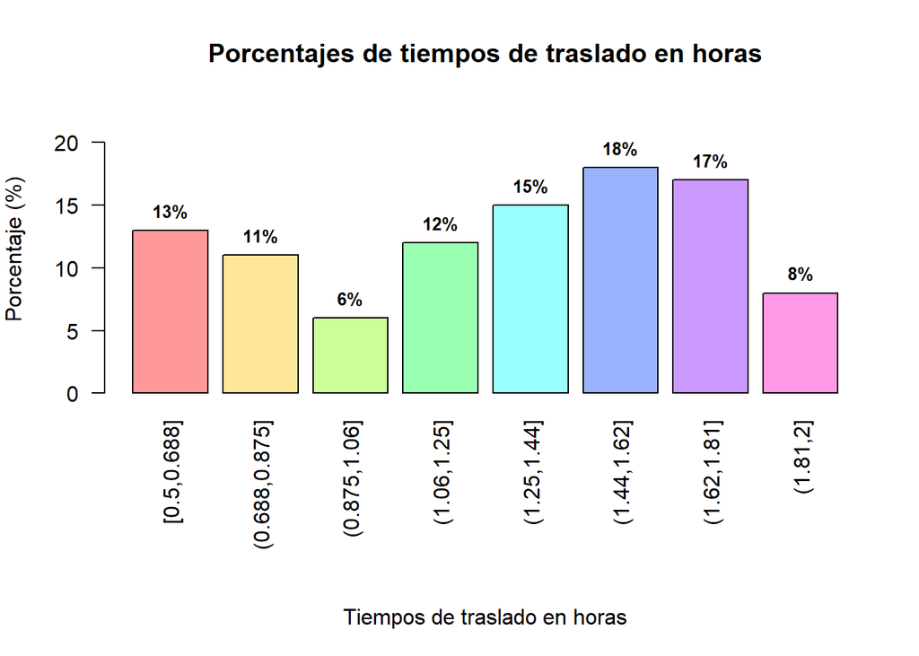

```r
par(mar=c(10,4,4,2))

intervalos <- cut(horas, breaks = breaks_exactos, include.lowest = TRUE)
tabla_intervalos <- table(intervalos)
porcentajes_intervalos <- round(prop.table(tabla_intervalos) * 100, 1)
gp <- barplot(porcentajes_intervalos,
                 col = rainbow(length(tabla_intervalos), 0.4),
                 main = "Porcentajes de tiempos de traslado en horas",
                 xlab = "",
                 ylab = "Porcentaje (%)",
                 ylim = c(0, max(porcentajes_intervalos) + 5),
                 las = 2)  # Etiquetas verticales

title(xlab = "Tiempos de traslado en horas", line = 8)

# Agregar valores encima de barras
text(x = gp,
     y = porcentajes_intervalos,
     labels = paste0(porcentajes_intervalos, "%"),
     pos = 3,
     cex = 0.8,
     font = 2)
```

#### Gráfica de pasteles

Generamos la gráfica de pasteles.

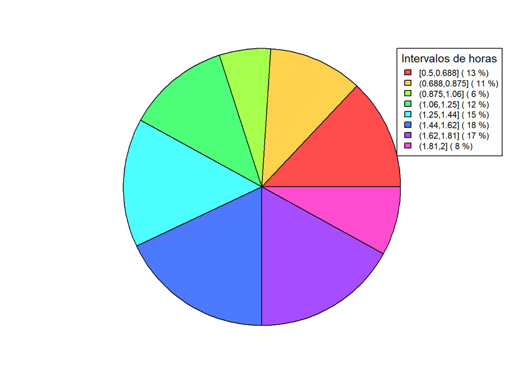

```r
par(pin = c(7, 5))
pie(tabla_intervalos,
    main = "Distribución de tiempos de traslado en horas",
    col = rainbow(length(tabla_intervalos), 0.7),
    labels = NA,
    cex.main = 1.5)

legend(x =0.78, y = 0.8,
       legend = paste(names(tabla_intervalos), "(", porcentajes_intervalos, "%)"),
       fill = rainbow(length(tabla_intervalos), 0.7),
       cex = 0.7,
       title = "Intervalos de horas",
       title.cex = 0.9)
```

#### Gráfica de ojiva

Generamos la gráfica de ojiva

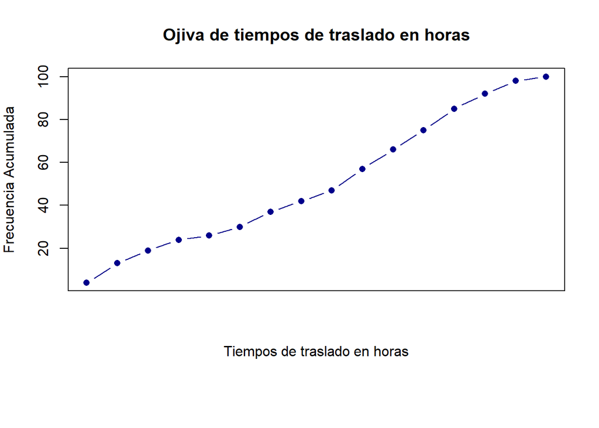

```r
par(mar=c(8,4,4,2))
frec_acum <- cumsum(table(factor(horas)))
plot(frec_acum, type = "b", pch = 16, col = "darkblue",
     main = "Ojiva de tiempos de traslado en horas",
     xlab = "Tiempos de traslado en horas",
     ylab = "Frecuencia Acumulada",
     xaxt = "n")
```

#### Gráfica de dispersión

```r
indices <- 1:10; (indices)
```

```
##  [1]  1  2  3  4  5  6  7  8  9 10
```

```r
t <- cte*indices; (t)
```

```
##  [1]  9 18 27 36 45 54 63 72 81 90
```

```r
mis_deciles <- tabla_intervalos[t]; (mis_deciles)
```

```
## intervalos
## <NA> <NA> <NA> <NA> <NA> <NA> <NA> <NA> <NA> <NA>
##
```

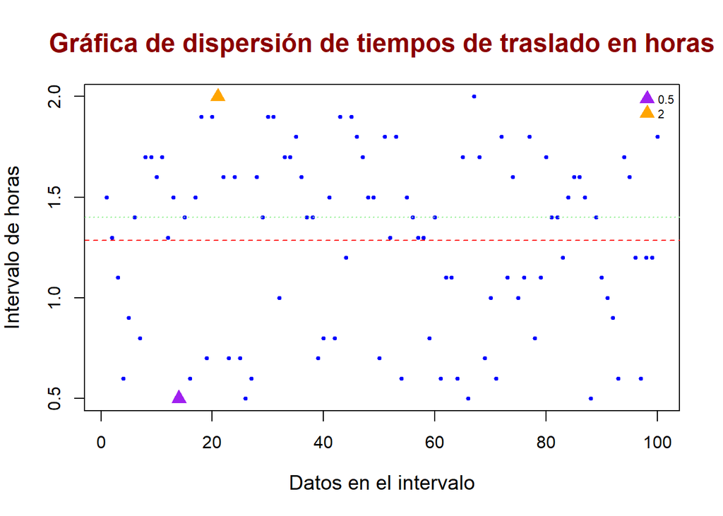

```r
plot(horas,
  main = "Gráfica de dispersión de tiempos de traslado en horas",
  xlab = "Datos en el intervalo",
  ylab = "Intervalo de horas",
  col = "blue",
  pch = 19,
  cex = 0.5,
  cex.main = 1.5,
  cex.lab = 1.2,
  col.main = "darkred")
legend(
  "topright",                  # ubicación
  legend = c(mi_min,mi_max),    # etiquetas
  pch = 17,
  col=c("purple","orange"),
  pt.cex = 1.5,                # tamaño de los símbolos
  cex = 0.7,
  bty = "n"                    # sin borde en la caja
)
abline(h = media, col = "red", lwd = 1, lty = 2)
abline(h = Q2, col = "lightgreen", lwd = 1, lty = 3)
abline(h = mis_deciles, col = "lightgray", lty = 1.5)
points(which.min(horas), min(horas), col = "purple", pch = 17, cex = 1.5)
points(which.max(horas), max(horas), col = "orange", pch = 17, cex = 1.5)
```

#### Gráfica combinada

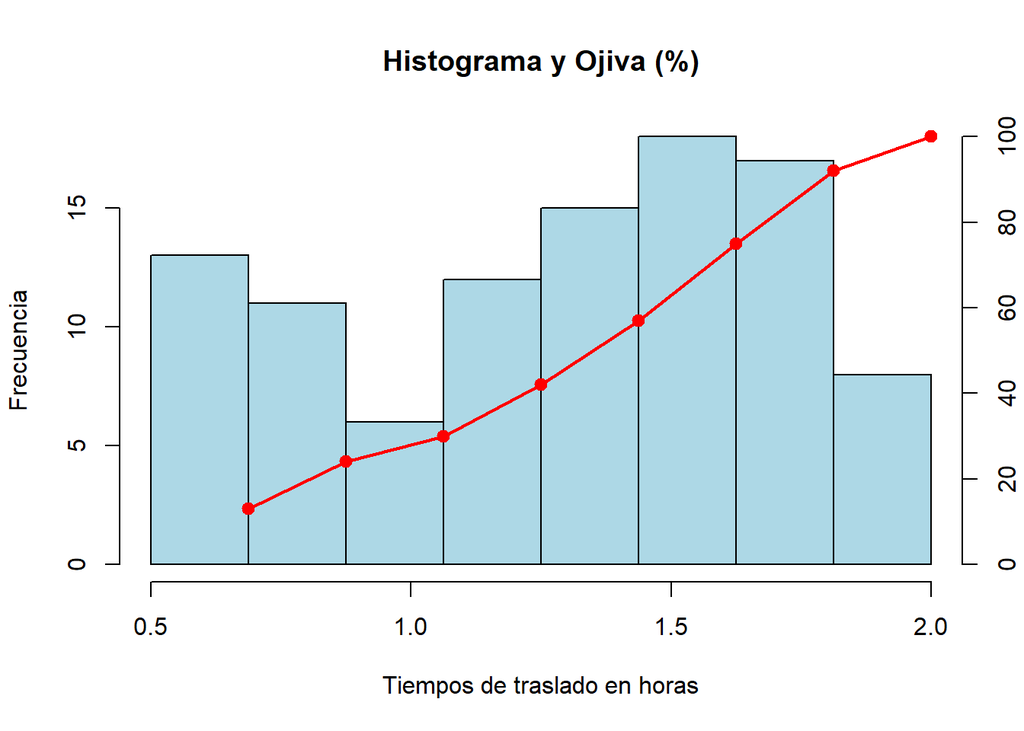

```r
nbreaks <- 10
h <- hist(horas, breaks = breaks_exactos, plot = FALSE)
hist(horas,
     breaks = breaks_exactos,
     col = "lightblue",
     main = "Histograma y Ojiva (%)",
     xlab = "Tiempos de traslado en horas",
     ylab = "Frecuencia")
freq_acum_pct <- cumsum(h$counts) / sum(h$counts) * 100
x_vals <- h$breaks[-1]
par(new = TRUE)
plot(x_vals, freq_acum_pct,
     type = "o", pch = 19, lwd = 2, col = "red",
     axes = FALSE, xlab = "", ylab = "",
     xlim = range(h$breaks), ylim = c(0, 100))
axis(4)                           # eje derecho
```

```r
#---- Fin ----
```

# Ejercicio 10: Binarias o dicotómicas

## Ejercicio 10.1 Licencia de conducir

### Datos

```r
licencia <- c("No", "Si", "No", "Si", "Si", "No", "Si", "No", "No", "No", "Si", "Si", "No", "No", "Si", "No", "No", "Si", "No", "No", "Si", "Si", "Si", "No", "No", "Si", "No", "Si", "No", "No", "No", "No", "Si", "Si", "No", "Si", "Si", "No", "Si", "Si", "No", "Si", "No", "No", "Si", "No", "No", "No", "No", "Si", "Si", "Si", "No", "Si", "No", "No", "No", "No", "Si", "Si", "No", "Si", "No", "Si", "No", "No", "No", "Si", "No", "Si", "No", "Si", "Si", "No", "No")
```

### Procesamiento de datos

Primero obtenemos un resumen de los datos generados

```r
summary(licencia)
```

```
##    Length     Class      Mode
##        75 character character
```

Al ser variables de tipo Binarias o Dicotómicas no se pueden ordenar ni se pueden obtener los deciles ni cuartiles.

### Frecuencias

Obtenemos las frecuencias de los datos.

```r
(licencia) #Datos
```

```
##  [1] "No" "Si" "No" "Si" "Si" "No" "Si" "No" "No" "No" "Si" "Si" "No" "No" "Si"
## [16] "No" "No" "Si" "No" "No" "Si" "Si" "Si" "No" "No" "Si" "No" "Si" "No" "No"
## [31] "No" "No" "Si" "Si" "No" "Si" "Si" "No" "Si" "Si" "No" "Si" "No" "No" "Si"
## [46] "No" "No" "No" "No" "Si" "Si" "Si" "No" "Si" "No" "No" "No" "No" "Si" "Si"
## [61] "No" "Si" "No" "Si" "No" "No" "No" "Si" "No" "Si" "No" "Si" "Si" "No" "No"
```

```r
sort(licencia) #Datos ordenados por clase
```

```
##  [1] "No" "No" "No" "No" "No" "No" "No" "No" "No" "No" "No" "No" "No" "No" "No"
## [16] "No" "No" "No" "No" "No" "No" "No" "No" "No" "No" "No" "No" "No" "No" "No"
## [31] "No" "No" "No" "No" "No" "No" "No" "No" "No" "No" "No" "No" "Si" "Si" "Si"
## [46] "Si" "Si" "Si" "Si" "Si" "Si" "Si" "Si" "Si" "Si" "Si" "Si" "Si" "Si" "Si"
## [61] "Si" "Si" "Si" "Si" "Si" "Si" "Si" "Si" "Si" "Si" "Si" "Si" "Si" "Si" "Si"
```

```r
contador <- table(licencia) #Frecuencia de los datos
(contador)
```

```
## licencia
## No Si
## 42 33
```

### Proporciones

Obtenemos las proporciones.

```r
prop.table(table(licencia)) #Proporciones
```

```
## licencia
##   No   Si
## 0.56 0.44
```

### Medidas de tendencia central

Obtenemos la moda

```r
# Función para detectar modalidad
max_frecuencia <- max(contador)
modas <- names(contador)[contador == max_frecuencia]

# Identificar e imprimir resultado
if(length(modas) == 1) {
  cat("UNIMODAL - Moda:", modas)
} else if(length(modas) == 2) {
  cat("BIMODAL - Modas:", paste(modas, collapse = " y "))
} else {
  cat("Hay más de dos clases con mayor frecuencia por lo tanto no hay moda")
}
```

```
## UNIMODAL - Moda: No
```

### Gráficos

Comenzamos a graficar.

#### Gráfica de barras

Generemos la gráfica de barras.

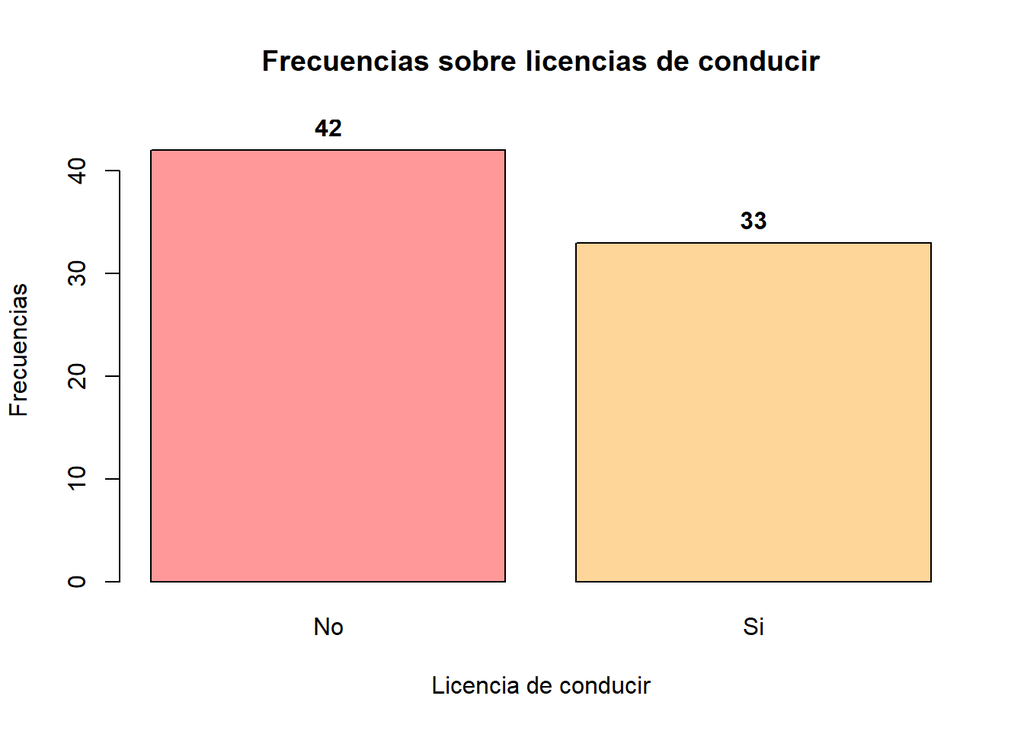

```r
gb<-barplot(contador, col=rainbow(10,0.4),
        main="Frecuencias sobre licencias de conducir",
        xlab="Licencia de conducir",
        ylab="Frecuencias",
        ylim=c(0,45),
        )
# Agregar valores encima de cada barra
text(x=gb,
     y=contador,
     labels=contador,
     pos=3,
     cex=1,
     font=2)
```

#### Gráfica de porcentajes

Generamos la gráfica de porcentajes.

```r
tabla <- table(licencia); (tabla)
```

```
## licencia
## No Si
## 42 33
```

```r
porcentajes <-  round(prop.table(tabla)* 100, 1); (porcentajes)
```

```
## licencia
## No Si
## 56 44
```

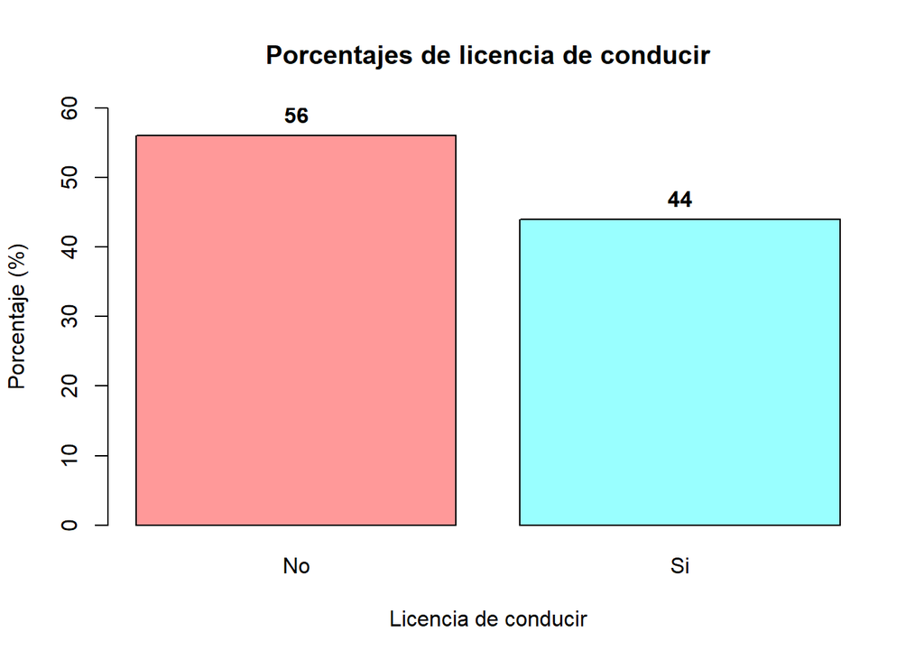

```r
gp<- barplot(porcentajes, col = rainbow(length(tabla),0.4),
    main = "Porcentajes de licencia de conducir",
    xlab = "Licencia de conducir",
    ylab="Porcentaje (%)",
    ylim=c(0,60),
        )
# Agregar valores encima de cada barra
text(x=gp,
     y=porcentajes,
     labels=porcentajes,
     pos=3,
     cex=1,
     font=2)
```

#### Gráfica de pasteles

Generamos la gráfica de pasteles.

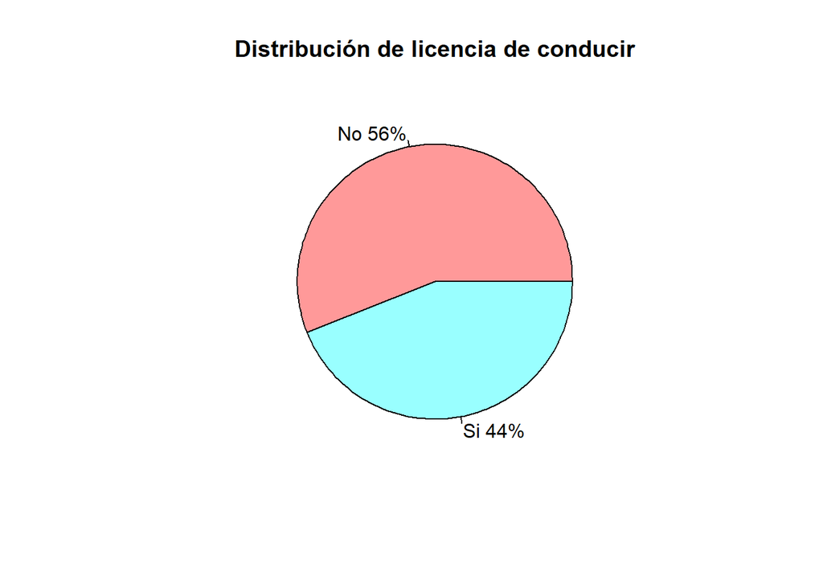

```r
pie(tabla,
    main = "Distribución de licencia de conducir",
    col = rainbow(length(tabla),0.4),
    labels = paste0(names(tabla)," ",porcentajes, "%"))
```

```r
#---- Fin ----
```

## Ejercicio 10.2 Examen

### Datos

```r
examen <- c("Reprobado", "Aprobado", "Aprobado", "Aprobado", "Aprobado", "Reprobado", "Aprobado", "Reprobado", "Reprobado", "Aprobado", "Reprobado", "Reprobado", "Reprobado", "Reprobado", "Aprobado", "Reprobado", "Reprobado", "Aprobado", "Aprobado", "Reprobado", "Aprobado", "Aprobado", "Aprobado", "Aprobado", "Reprobado", "Aprobado", "Reprobado", "Aprobado", "Reprobado", "Reprobado", "Aprobado", "Reprobado", "Aprobado", "Reprobado", "Aprobado", "Reprobado", "Reprobado", "Aprobado", "Reprobado", "Reprobado", "Reprobado", "Aprobado", "Aprobado", "Aprobado", "Aprobado", "Reprobado", "Reprobado", "Reprobado", "Aprobado", "Reprobado")
```

### Procesamiento de datos

Primero obtenemos un resumen de los datos generados

```r
summary(examen)
```

```
##    Length     Class      Mode
##        50 character character
```

Al ser variables de tipo Binarias o Dicotómicas no se pueden ordenar ni se pueden obtener los deciles ni cuartiles.

### Frecuencias

Obtenemos las frecuencias de los datos.

```r
(examen) #Datos
```

```
##  [1] "Reprobado" "Aprobado"  "Aprobado"  "Aprobado"  "Aprobado"  "Reprobado"
##  [7] "Aprobado"  "Reprobado" "Reprobado" "Aprobado"  "Reprobado" "Reprobado"
## [13] "Reprobado" "Reprobado" "Aprobado"  "Reprobado" "Reprobado" "Aprobado"
## [19] "Aprobado"  "Reprobado" "Aprobado"  "Aprobado"  "Aprobado"  "Aprobado"
## [25] "Reprobado" "Aprobado"  "Reprobado" "Aprobado"  "Reprobado" "Reprobado"
## [31] "Aprobado"  "Reprobado" "Aprobado"  "Reprobado" "Aprobado"  "Reprobado"
## [37] "Reprobado" "Aprobado"  "Reprobado" "Reprobado" "Reprobado" "Aprobado"
## [43] "Aprobado"  "Aprobado"  "Aprobado"  "Reprobado" "Reprobado" "Reprobado"
## [49] "Aprobado"  "Reprobado"
```

```r
sort(examen) #Datos ordenados por clase
```

```
##  [1] "Aprobado"  "Aprobado"  "Aprobado"  "Aprobado"  "Aprobado"  "Aprobado"
##  [7] "Aprobado"  "Aprobado"  "Aprobado"  "Aprobado"  "Aprobado"  "Aprobado"
## [13] "Aprobado"  "Aprobado"  "Aprobado"  "Aprobado"  "Aprobado"  "Aprobado"
## [19] "Aprobado"  "Aprobado"  "Aprobado"  "Aprobado"  "Aprobado"  "Aprobado"
## [25] "Reprobado" "Reprobado" "Reprobado" "Reprobado" "Reprobado" "Reprobado"
## [31] "Reprobado" "Reprobado" "Reprobado" "Reprobado" "Reprobado" "Reprobado"
## [37] "Reprobado" "Reprobado" "Reprobado" "Reprobado" "Reprobado" "Reprobado"
## [43] "Reprobado" "Reprobado" "Reprobado" "Reprobado" "Reprobado" "Reprobado"
## [49] "Reprobado" "Reprobado"
```

```r
contador <- table(examen) #Frecuencia de los datos
(contador)
```

```
## examen
##  Aprobado Reprobado
##        24        26
```

### Proporciones

Obtenemos las proporciones.

```r
prop.table(table(examen)) #Proporciones
```

```
## examen
##  Aprobado Reprobado
##      0.48      0.52
```

### Medidas de tendencia central

Obtenemos la moda

```r
# Función para detectar modalidad
max_frecuencia <- max(contador)
modas <- names(contador)[contador == max_frecuencia]

# Identificar e imprimir resultado
if(length(modas) == 1) {
  cat("UNIMODAL - Moda:", modas)
} else if(length(modas) == 2) {
  cat("BIMODAL - Modas:", paste(modas, collapse = " y "))
} else {
  cat("Hay más de dos clases con mayor frecuencia por lo tanto no hay moda")
}
```

```
## UNIMODAL - Moda: Reprobado
```

### Gráficos

Comenzamos a graficar.

#### Gráfica de barras*

Generemos la gráfica de barras.

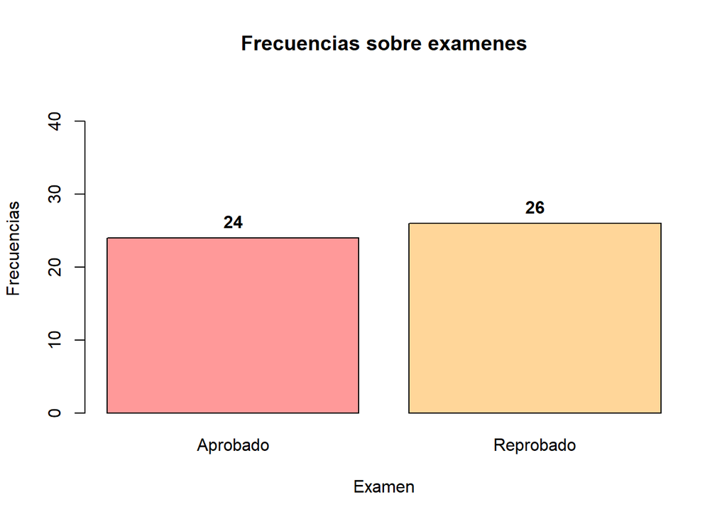

```r
gb<-barplot(contador, col=rainbow(10,0.4),
        main="Frecuencias sobre examenes",
        xlab="Examen",
        ylab="Frecuencias",
        ylim=c(0,45),
        )
# Agregar valores encima de cada barra
text(x=gb,
     y=contador,
     labels=contador,
     pos=3,
     cex=1,
     font=2)
```

#### Gráfica de porcentajes

Generamos la gráfica de porcentajes.

```r
tabla <- table(examen); (tabla)
```

```
## examen
##  Aprobado Reprobado
##        24        26
```

```r
porcentajes <-  round(prop.table(tabla)* 100, 1); (porcentajes)
```

```
## examen
##  Aprobado Reprobado
##        48        52
```

[figure not shown]

```r
gp<- barplot(porcentajes, col = rainbow(length(tabla),0.4),
    main = "Porcentajes de licencia de conducir",
    xlab = "Licencia de conducir",
    ylab="Porcentaje (%)",
    ylim=c(0,60),
        )
# Agregar valores encima de cada barra
text(x=gp,
     y=porcentajes,
     labels=porcentajes,
     pos=3,
     cex=1,
     font=2)
```

#### Gráfica de pasteles

Generamos la gráfica de pasteles.

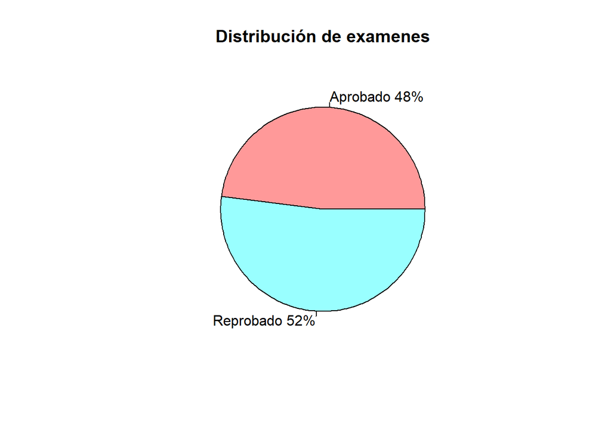

```r
pie(tabla,
    main = "Distribución de examenes",
    col = rainbow(length(tabla),0.4),
    labels = paste0(names(tabla)," ",porcentajes, "%"))
```

```r
#---- Fin ----
```

## Ejercicio 10.3 COVID

### Datos

```r
covid <- c("Negativo", "Positivo", "Negativo", "Negativo", "Negativo", "Positivo", "Positivo", "Negativo", "Negativo", "Positivo", "Negativo", "Positivo", "Positivo", "Negativo", "Negativo", "Negativo", "Negativo", "Negativo", "Negativo", "Negativo", "Positivo", "Positivo", "Negativo", "Negativo", "Positivo", "Negativo", "Positivo", "Negativo", "Negativo", "Positivo", "Positivo", "Negativo", "Positivo", "Positivo", "Negativo", "Positivo", "Negativo", "Negativo", "Negativo", "Negativo", "Positivo", "Negativo", "Positivo", "Negativo", "Negativo", "Negativo", "Negativo", "Negativo", "Negativo", "Negativo")
```

### Procesamiento de datos

Primero obtenemos un resumen de los datos generados

```r
summary(covid)
```

```
##    Length     Class      Mode
##        50 character character
```

Al ser variables de tipo Binarias o Dicotómicas no se pueden ordenar ni se pueden obtener los deciles ni cuartiles.

### Frecuencias

Obtenemos las frecuencias de los datos.

```r
(covid) #Datos
```

```
##  [1] "Negativo" "Positivo" "Negativo" "Negativo" "Negativo" "Positivo"
##  [7] "Positivo" "Negativo" "Negativo" "Positivo" "Negativo" "Positivo"
## [13] "Positivo" "Negativo" "Negativo" "Negativo" "Negativo" "Negativo"
## [19] "Negativo" "Negativo" "Positivo" "Positivo" "Negativo" "Negativo"
## [25] "Positivo" "Negativo" "Positivo" "Negativo" "Negativo" "Positivo"
## [31] "Positivo" "Negativo" "Positivo" "Positivo" "Negativo" "Positivo"
## [37] "Negativo" "Negativo" "Negativo" "Negativo" "Positivo" "Negativo"
## [43] "Positivo" "Negativo" "Negativo" "Negativo" "Negativo" "Negativo"
## [49] "Negativo" "Negativo"
```

```r
sort(covid) #Datos ordenados por clase
```

```
##  [1] "Negativo" "Negativo" "Negativo" "Negativo" "Negativo" "Negativo"
##  [7] "Negativo" "Negativo" "Negativo" "Negativo" "Negativo" "Negativo"
## [13] "Negativo" "Negativo" "Negativo" "Negativo" "Negativo" "Negativo"
## [19] "Negativo" "Negativo" "Negativo" "Negativo" "Negativo" "Negativo"
## [25] "Negativo" "Negativo" "Negativo" "Negativo" "Negativo" "Negativo"
## [31] "Negativo" "Negativo" "Negativo" "Positivo" "Positivo" "Positivo"
## [37] "Positivo" "Positivo" "Positivo" "Positivo" "Positivo" "Positivo"
## [43] "Positivo" "Positivo" "Positivo" "Positivo" "Positivo" "Positivo"
## [49] "Positivo" "Positivo"
```

```r
contador <- table(covid) #Frecuencia de los datos
(contador)
```

```
## covid
## Negativo Positivo
##       33       17
```

### Proporciones

Obtenemos las proporciones.

```r
prop.table(table(covid)) #Proporciones
```

```
## covid
## Negativo Positivo
##     0.66     0.34
```

### Medidas de tendencia central

Obtenemos la moda

```r
# Función para detectar modalidad
max_frecuencia <- max(contador)
modas <- names(contador)[contador == max_frecuencia]

# Identificar e imprimir resultado
if(length(modas) == 1) {
  cat("UNIMODAL - Moda:", modas)
} else if(length(modas) == 2) {
  cat("BIMODAL - Modas:", paste(modas, collapse = " y "))
} else {
  cat("Hay más de dos clases con mayor frecuencia por lo tanto no hay moda")
}
```

```
## UNIMODAL - Moda: Negativo
```

### Gráficos

Comenzamos a graficar.

#### Gráfica de barras*

Generemos la gráfica de barras.

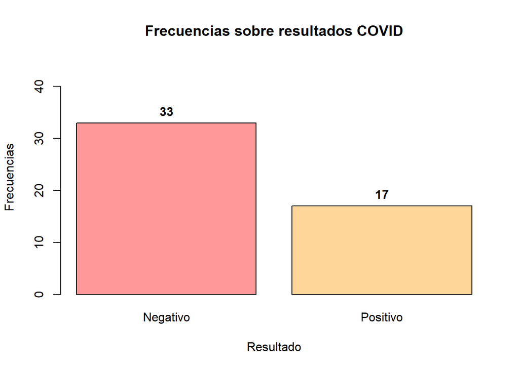

```r
gb<-barplot(contador, col=rainbow(10,0.4),
        main="Frecuencias sobre resultados COVID",
        xlab="Resultado",
        ylab="Frecuencias",
        ylim=c(0,45),
        )
# Agregar valores encima de cada barra
text(x=gb,
     y=contador,
     labels=contador,
     pos=3,
     cex=1,
     font=2)
```

#### Gráfica de porcentajes

Generamos la gráfica de porcentajes.

```r
tabla <- table(covid); (tabla)
```

```
## covid
## Negativo Positivo
##       33       17
```

```r
porcentajes <-  round(prop.table(tabla)* 100, 1); (porcentajes)
```

```
## covid
## Negativo Positivo
##       66       34
```

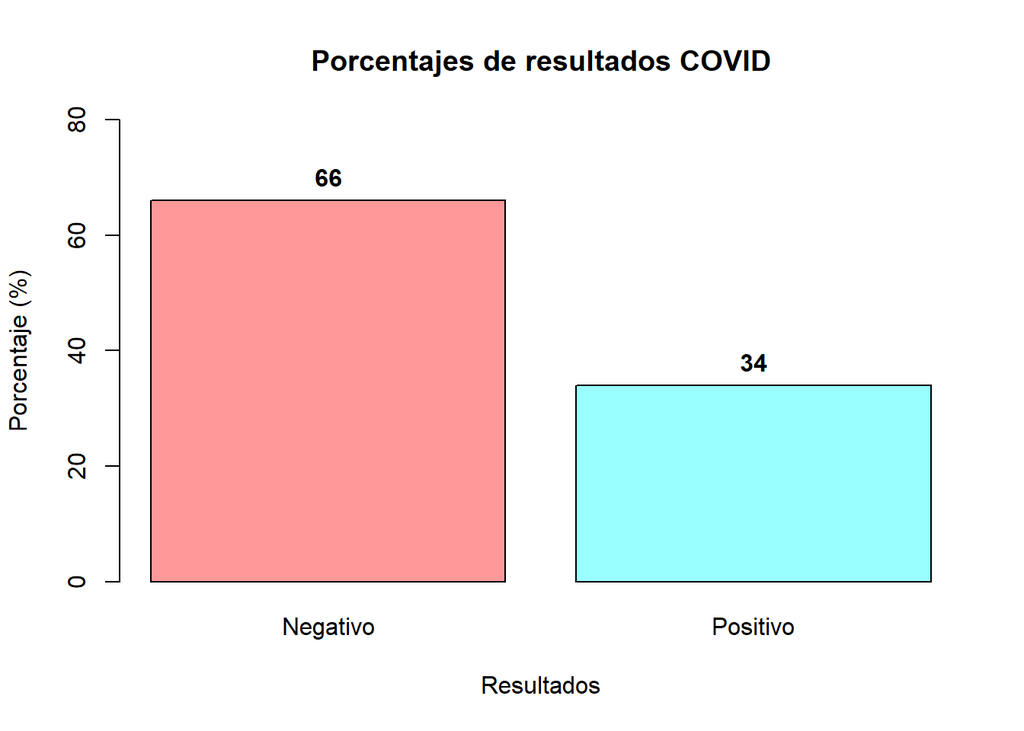

```r
gp<- barplot(porcentajes, col = rainbow(length(tabla),0.4),
    main = "Porcentajes de resultados COVID",
    xlab = "Resultados",
    ylab="Porcentaje (%)",
    ylim=c(0,80),
    )
# Agregar valores encima de cada barra
text(x=gp,
     y=porcentajes,
     labels=porcentajes,
     pos=3,
     cex=1,
     font=2)
```

#### Gráfica de pasteles

Generamos la gráfica de pasteles.

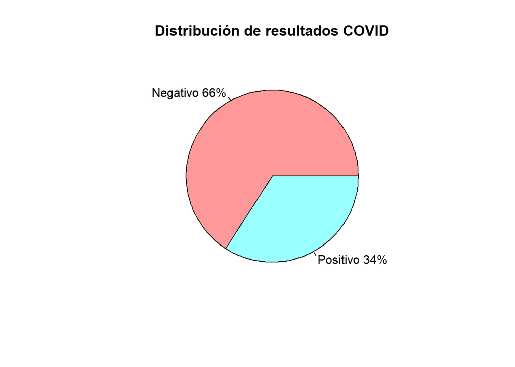

```r
pie(tabla,
    main = "Distribución de resultados COVID",
    col = rainbow(length(tabla),0.4),
    labels = paste0(names(tabla)," ",porcentajes, "%"))
```

```r
#---- Fin ----
```

# Ejercicio 11: Politómicas

## Ejercicio 11.1 Tipo de sangre

### Datos

```r
tipo <- c("A-", "AB-", "AB+", "B+", "O-", "O+", "B+", "A-", "O-", "B-", "A-", "A-", "O+", "A+", "O+", "AB+", "B+", "AB+", "AB-", "B-", "O-", "O+", "B+", "O+", "O+", "O+", "A+", "O-", "AB-", "A-", "B+", "O-", "B-", "A-", "A-", "AB-", "B+", "AB-", "A-", "B+", "A-", "AB-", "O-", "AB+", "B+", "O+", "B-", "O-", "A-", "AB-", "O+", "AB+", "AB+", "B+", "O-", "AB+", "AB+", "AB-", "A-", "O-", "AB+", "AB+", "A+", "A+", "O+", "B+", "AB-", "O-", "A-", "A+", "A+", "B-", "B-", "B-", "A+", "A-", "AB-", "A-", "A-", "AB+")
```

### Procesamiento de datos

Primero obtenemos un resumen de los datos generados

```r
summary(tipo)
```

```
##    Length     Class      Mode
##        80 character character
```

### Frecuencias

Obtenemos las frecuencias de los datos.

```r
(tipo) #Datos
```

```
##  [1] "A-"  "AB-" "AB+" "B+"  "O-"  "O+"  "B+"  "A-"  "O-"  "B-"  "A-"  "A-"
## [13] "O+"  "A+"  "O+"  "AB+" "B+"  "AB+" "AB-" "B-"  "O-"  "O+"  "B+"  "O+"
## [25] "O+"  "O+"  "A+"  "O-"  "AB-" "A-"  "B+"  "O-"  "B-"  "A-"  "A-"  "AB-"
## [37] "B+"  "AB-" "A-"  "B+"  "A-"  "AB-" "O-"  "AB+" "B+"  "O+"  "B-"  "O-"
## [49] "A-"  "AB-" "O+"  "AB+" "AB+" "B+"  "O-"  "AB+" "AB+" "AB-" "A-"  "O-"
## [61] "AB+" "AB+" "A+"  "A+"  "O+"  "B+"  "AB-" "O-"  "A-"  "A+"  "A+"  "B-"
## [73] "B-"  "B-"  "A+"  "A-"  "AB-" "A-"  "A-"  "AB+"
```

```r
sort(tipo) #Datos ordenados por clase
```

```
##  [1] "A-"  "A-"  "A-"  "A-"  "A-"  "A-"  "A-"  "A-"  "A-"  "A-"  "A-"  "A-"
## [13] "A-"  "A-"  "A-"  "A+"  "A+"  "A+"  "A+"  "A+"  "A+"  "A+"  "AB-" "AB-"
## [25] "AB-" "AB-" "AB-" "AB-" "AB-" "AB-" "AB-" "AB-" "AB+" "AB+" "AB+" "AB+"
## [37] "AB+" "AB+" "AB+" "AB+" "AB+" "AB+" "AB+" "B-"  "B-"  "B-"  "B-"  "B-"
## [49] "B-"  "B-"  "B+"  "B+"  "B+"  "B+"  "B+"  "B+"  "B+"  "B+"  "B+"  "B+"
## [61] "O-"  "O-"  "O-"  "O-"  "O-"  "O-"  "O-"  "O-"  "O-"  "O-"  "O+"  "O+"
## [73] "O+"  "O+"  "O+"  "O+"  "O+"  "O+"  "O+"  "O+"
```

```r
contador <- table(tipo) #Frecuencia de los datos
(contador)
```

```
## tipo
##  A-  A+ AB- AB+  B-  B+  O-  O+
##  15   7  10  11   7  10  10  10
```

### Proporciones

Obtenemos las proporciones.

```r
prop.table(table(tipo)) #Proporciones
```

```
## tipo
##     A-     A+    AB-    AB+     B-     B+     O-     O+
## 0.1875 0.0875 0.1250 0.1375 0.0875 0.1250 0.1250 0.1250
```

### Medidas de tendencia central

Obtenemos la moda

```r
# Función para detectar modalidad
max_frecuencia <- max(contador)
modas <- names(contador)[contador == max_frecuencia]

# Identificar e imprimir resultado
if(length(modas) == 1) {
  cat("UNIMODAL - Moda:", modas)
} else if(length(modas) == 2) {
  cat("BIMODAL - Modas:", paste(modas, collapse = " y "))
} else {
  cat("Hay más de dos clases con mayor frecuencia por lo tanto no hay moda")
}
```

```
## UNIMODAL - Moda: A-
```

### Gráficos

Comenzamos a graficar.

#### Gráfica de barras*

Generemos la gráfica de barras.

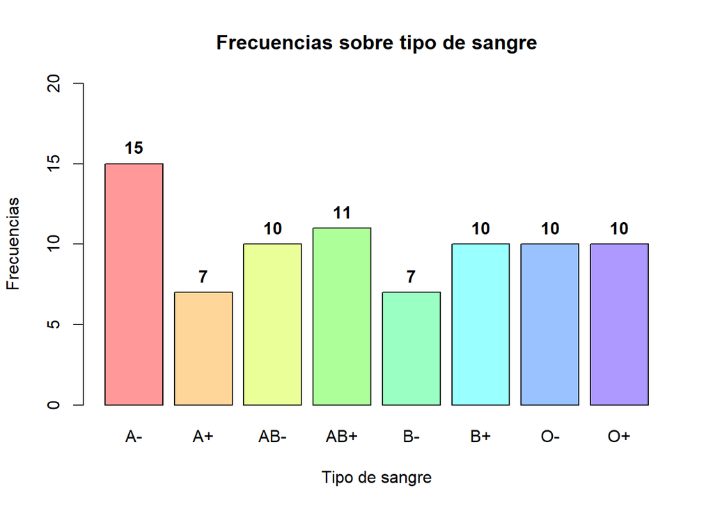

```r
gb<-barplot(contador, col=rainbow(10,0.4),
        main="Frecuencias sobre tipo de sangre",
        xlab="Tipo de sangre",
        ylab="Frecuencias",
        ylim=c(0,20),
        )
# Agregar valores encima de cada barra
text(x=gb,
     y=contador,
     labels=contador,
     pos=3,
     cex=1,
     font=2)
```

#### Gráfica de porcentajes

Generamos la gráfica de porcentajes.

```r
tabla <- table(tipo); (tabla)
```

```
## tipo
##  A-  A+ AB- AB+  B-  B+  O-  O+
##  15   7  10  11   7  10  10  10
```

```r
porcentajes <-  round(prop.table(tabla)* 100, 1); (porcentajes)
```

```
## tipo
##   A-   A+  AB-  AB+   B-   B+   O-   O+
## 18.8  8.8 12.5 13.8  8.8 12.5 12.5 12.5
```

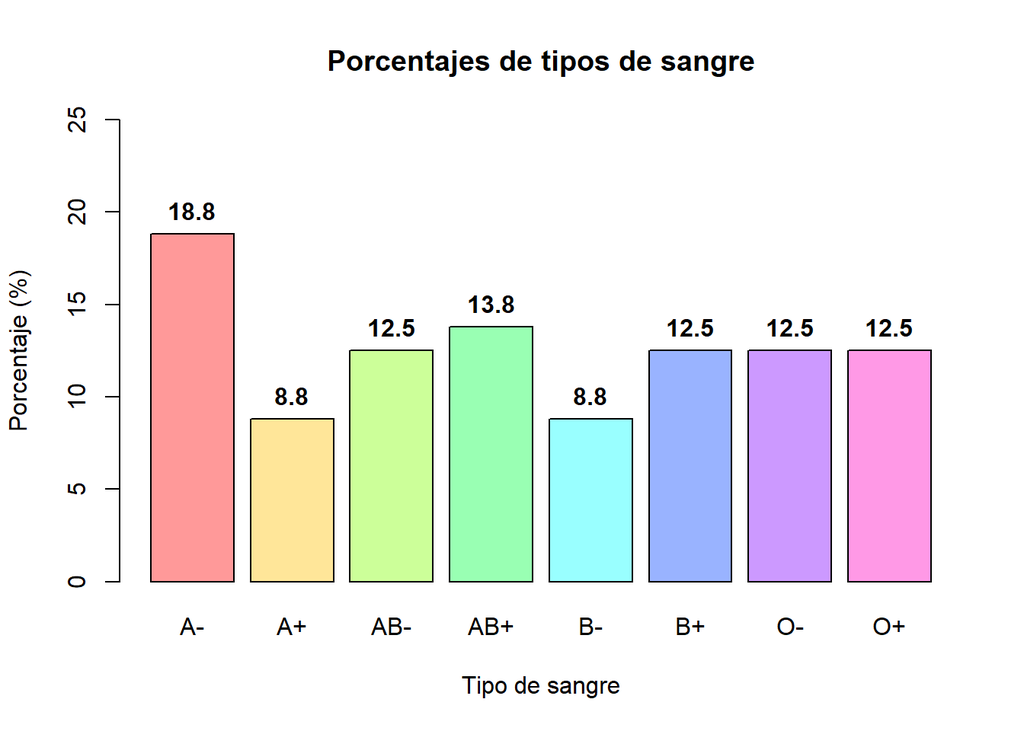

```r
gp<- barplot(porcentajes, col = rainbow(length(tabla),0.4),
    main = "Porcentajes de tipos de sangre",
    xlab = "Tipo de sangre",
    ylab="Porcentaje (%)",
    ylim=c(0,25),
    )
# Agregar valores encima de cada barra
text(x=gp,
     y=porcentajes,
     labels=porcentajes,
     pos=3,
     cex=1,
     font=2)
```

#### Gráfica de pasteles

Generamos la gráfica de pasteles.

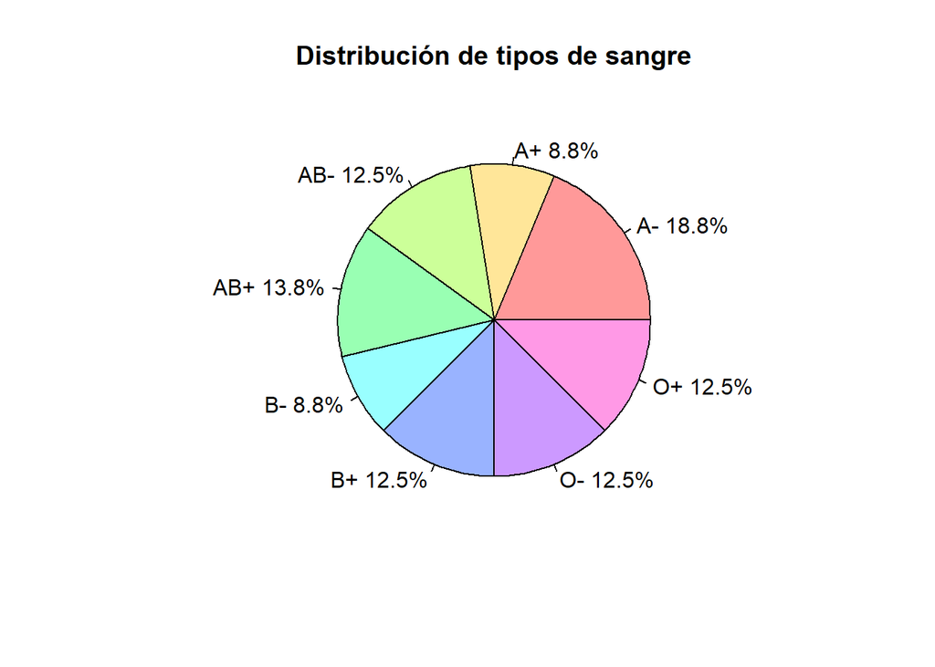

```r
pie(tabla,
    main = "Distribución de tipos de sangre",
    col = rainbow(length(tabla),0.4),
    labels = paste0(names(tabla)," ",porcentajes, "%"))
```

```r
#---- Fin ----
```

## Ejercicio 11.2: Ocupación

### Datos

```r
ocupacion <- c("Desempleado", "Estudiante", "Empleado", "Empleado", "Estudiante", "Empleado",
"Empleado", "Empleado", "Jubilado", "Jubilado", "Jubilado", "Jubilado", "Jubilado", "Estudiante",
"Desempleado", "Desempleado", "Jubilado", "Empleado", "Estudiante", "Estudiante", "Empleado",
"Desempleado", "Estudiante", "Desempleado", "Jubilado", "Empleado", "Jubilado", "Desempleado",
"Desempleado", "Desempleado")
```

### Procesamiento de datos

Primero obtenemos un resumen de los datos generados

```r
summary(ocupacion)
```

```
##    Length     Class      Mode
##        30 character character
```

### Frecuencias

Obtenemos las frecuencias de los datos.

```r
(ocupacion) #Datos
```

```
##  [1] "Desempleado" "Estudiante"  "Empleado"    "Empleado"    "Estudiante"
##  [6] "Empleado"    "Empleado"    "Empleado"    "Jubilado"    "Jubilado"
## [11] "Jubilado"    "Jubilado"    "Jubilado"    "Estudiante"  "Desempleado"
## [16] "Desempleado" "Jubilado"    "Empleado"    "Estudiante"  "Estudiante"
## [21] "Empleado"    "Desempleado" "Estudiante"  "Desempleado" "Jubilado"
## [26] "Empleado"    "Jubilado"    "Desempleado" "Desempleado" "Desempleado"
```

```r
sort(ocupacion) #Datos ordenados por clase
```

```
##  [1] "Desempleado" "Desempleado" "Desempleado" "Desempleado" "Desempleado"
##  [6] "Desempleado" "Desempleado" "Desempleado" "Empleado"    "Empleado"
## [11] "Empleado"    "Empleado"    "Empleado"    "Empleado"    "Empleado"
## [16] "Empleado"    "Estudiante"  "Estudiante"  "Estudiante"  "Estudiante"
## [21] "Estudiante"  "Estudiante"  "Jubilado"    "Jubilado"    "Jubilado"
## [26] "Jubilado"    "Jubilado"    "Jubilado"    "Jubilado"    "Jubilado"
```

```r
contador <- table(ocupacion) #Frecuencia de los datos
(contador)
```

```
## ocupacion
## Desempleado    Empleado  Estudiante    Jubilado
##           8           8           6           8
```

### Proporciones

Obtenemos las proporciones.

```r
prop.table(table(ocupacion)) #Proporciones
```

```
## ocupacion
## Desempleado    Empleado  Estudiante    Jubilado
##   0.2666667   0.2666667   0.2000000   0.2666667
```

### Medidas de tendencia central

Obtenemos la moda

```r
# Función para detectar modalidad
max_frecuencia <- max(contador)
modas <- names(contador)[contador == max_frecuencia]

# Identificar e imprimir resultado
if(length(modas) == 1) {
  cat("UNIMODAL - Moda:", modas)
} else if(length(modas) == 2) {
  cat("BIMODAL - Modas:", paste(modas, collapse = " y "))
} else {
  cat("Hay más de dos clases con mayor frecuencia por lo tanto no hay moda")
}
```

```
## Hay más de dos clases con mayor frecuencia por lo tanto no hay moda
```

### Gráficos

Comenzamos a graficar.

#### Gráfica de barras*

Generemos la gráfica de barras.

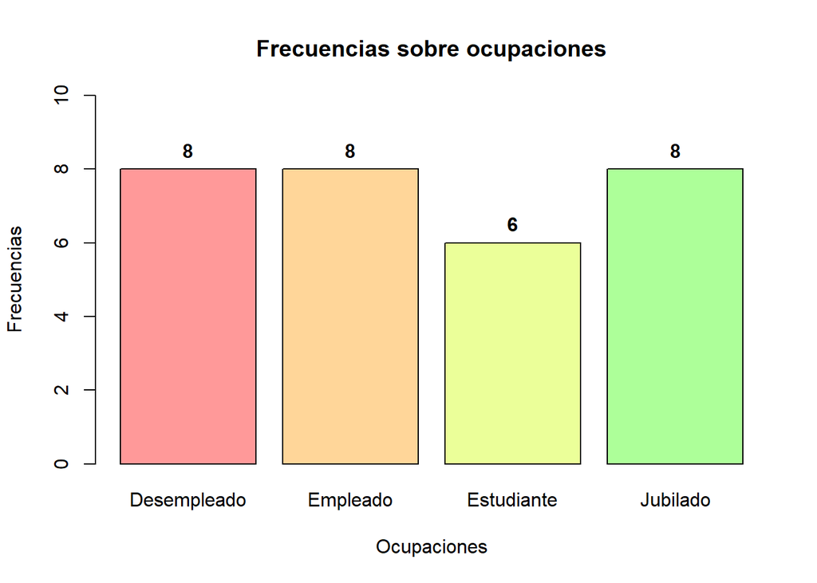

```r
gb<-barplot(contador, col=rainbow(10,0.4),
        main="Frecuencias sobre ocupaciones",
        xlab="Ocupaciones",
        ylab="Frecuencias",
        ylim=c(0,10),
        )
# Agregar valores encima de cada barra
text(x=gb,
     y=contador,
     labels=contador,
     pos=3,
     cex=1,
     font=2)
```

#### Gráfica de porcentajes

Generamos la gráfica de porcentajes.

```r
tabla <- table(ocupacion); (tabla)
```

```
## ocupacion
## Desempleado    Empleado  Estudiante    Jubilado
##           8           8           6           8
```

```r
porcentajes <-  round(prop.table(tabla)* 100, 1); (porcentajes)
```

```
## ocupacion
## Desempleado    Empleado  Estudiante    Jubilado
##        26.7        26.7        20.0        26.7
```

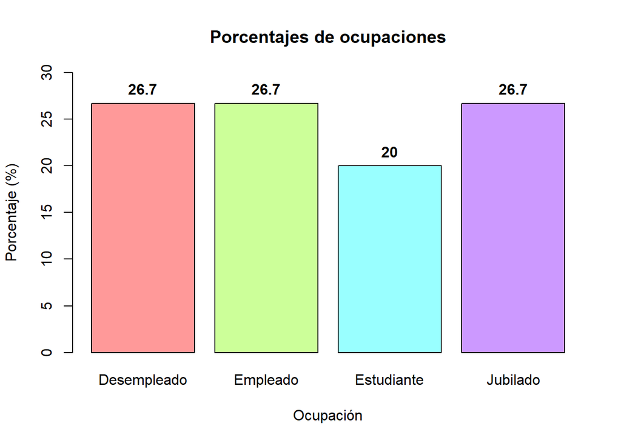

```r
gp<- barplot(porcentajes, col = rainbow(length(tabla),0.4),
    main = "Porcentajes de ocupaciones",
    xlab = "Ocupación",
    ylab="Porcentaje (%)",
    ylim=c(0,30),
    )
# Agregar valores encima de cada barra
text(x=gp,
     y=porcentajes,
     labels=porcentajes,
     pos=3,
     cex=1,
     font=2)
```

#### Gráfica de pasteles

Generamos la gráfica de pasteles.

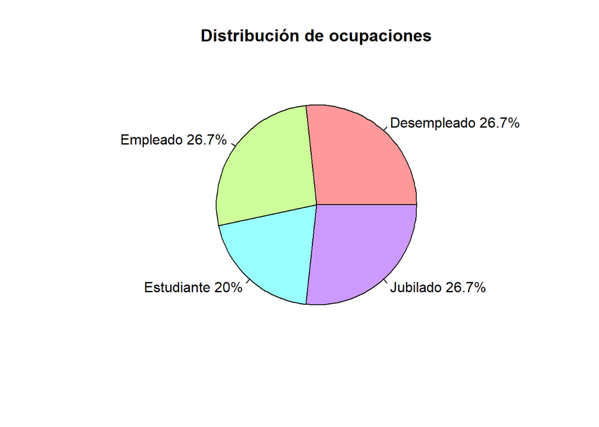

```r
pie(tabla,
    main = "Distribución de ocupaciones",
    col = rainbow(length(tabla),0.4),
    labels = paste0(names(tabla)," ",porcentajes, "%"))
```

```r
#---- Fin ----
```